# STAT 420 Final Project: Analysis of Video Game Sales

Dangelo Feliciano, Anirudh Eswara

2026-05-09

## 1. Introduction

The dataset is comprised of the following variables:

- `Name` - Name of the game (e.g., Wii Sports, Super Mario Bros., Mario Kart Wii, etc)
- `Platform` - Console on which the game is running (e.g., Wii, NES, GB, etc)
- `Year_of_Release` - Year that the game was released (1980-2020)
- `Genre` - Game’s category (e.g., Sports, Platform, Racing, etc)
- `Publisher` - Publisher of the game (e.g., Nintendo, Microsoft Game Studios, Take-Two Interactive, etc)
- `NA_Sales` - Game sales in North America (in millions of units)
- `EU_Sales` - Game sales in the European Union (in millions of units)
- `JP_Sales` - Game sales in Japan (in millions of units)
- `Other_Sales` - Game sales in the rest of the world, i.e., Africa, Asia excluding Japan, Australia, and Europe excluding the EU)
- `Global_Sales` - Global game sales (in millions of units)
- `Critic_Score` - Average score of Metacritic’s staff where each score is in the range of 0 to 100
- `Critic Count` - Number of critics who gave a `Critic_Score`
- `User_Score` - Average score of Metacritic’s subscribers where each score is in the range of 0 to 10
- `User_Count` - Number of users who gave a `User_Score`
- `Developer` - The video game developer that created the game (e.g., Nintendo, Good Science Studio, Rockstar North, etc.)
- `Rating` - ESRB rating (e.g., Everyone, Teen, Adults Only, etc.)

The goal of this analysis is to predict a video game’s global sales (`Global_Sales`) using a subset of its other metadata attributes. Our analysis will explore how these other attributes relate to game sales as well as how they relate and interact with one another. By modelling the relationship between a video game’s global sales and its other metadata attributes, video game developers and/or publishers can use information gathered from the game’s pre-release (e.g., user and critic scores) and other information related the game (e.g., platform, genre, rating) to predict future sales and therefore be able to make improved business decisions.

## 2. Methods

```r
library(tidyverse)
library(scales)
library(knitr)

source(here::here("R", "01_load_clean.R"))
```

### 2a. Setup

#### Load Raw Data

```r
raw <- load_raw()
glimpse(raw)
```

```
## Rows: 16,719
## Columns: 16
## $ Name            <chr> "Wii Sports", "Super Mario Bros.", "Mario Kart Wii", "…
## $ Platform        <chr> "Wii", "NES", "Wii", "Wii", "GB", "GB", "DS", "Wii", "…
## $ Year_of_Release <chr> "2006", "1985", "2008", "2009", "1996", "1989", "2006"…
## $ Genre           <chr> "Sports", "Platform", "Racing", "Sports", "Role-Playin…
## $ Publisher       <chr> "Nintendo", "Nintendo", "Nintendo", "Nintendo", "Ninte…
## $ NA_Sales        <dbl> 41.36, 29.08, 15.68, 15.61, 11.27, 23.20, 11.28, 13.96…
## $ EU_Sales        <dbl> 28.96, 3.58, 12.76, 10.93, 8.89, 2.26, 9.14, 9.18, 6.9…
## $ JP_Sales        <dbl> 3.77, 6.81, 3.79, 3.28, 10.22, 4.22, 6.50, 2.93, 4.70,…
## $ Other_Sales     <dbl> 8.45, 0.77, 3.29, 2.95, 1.00, 0.58, 2.88, 2.84, 2.24, …
## $ Global_Sales    <dbl> 82.53, 40.24, 35.52, 32.77, 31.37, 30.26, 29.80, 28.92…
## $ Critic_Score    <dbl> 76, NA, 82, 80, NA, NA, 89, 58, 87, NA, NA, 91, NA, 80…
## $ Critic_Count    <dbl> 51, NA, 73, 73, NA, NA, 65, 41, 80, NA, NA, 64, NA, 63…
## $ User_Score      <chr> "8", NA, "8.3", "8", NA, NA, "8.5", "6.6", "8.4", NA, …
## $ User_Count      <dbl> 322, NA, 709, 192, NA, NA, 431, 129, 594, NA, NA, 464,…
## $ Developer       <chr> "Nintendo", NA, "Nintendo", "Nintendo", NA, NA, "Ninte…
## $ Rating          <chr> "E", NA, "E", "E", NA, NA, "E", "E", "E", NA, NA, "E",…
```

#### Missing Value Overview

```r
col_summary(raw) %>%
  arrange(desc(null_pct)) %>%
  kable(digits = 2, caption = "Missing Values — Raw Dataset")
```

Missing Values — Raw Dataset

| column | dtype | non_null | null_n | null_pct |
| --- | --- | --- | --- | --- |
| User_Count | numeric | 7590 | 9129 | 54.60 |
| Critic_Score | numeric | 8137 | 8582 | 51.33 |
| Critic_Count | numeric | 8137 | 8582 | 51.33 |
| Rating | character | 9950 | 6769 | 40.49 |
| User_Score | character | 10015 | 6704 | 40.10 |
| Developer | character | 10096 | 6623 | 39.61 |
| Year_of_Release | character | 16450 | 269 | 1.61 |
| Publisher | character | 16665 | 54 | 0.32 |
| Name | character | 16717 | 2 | 0.01 |
| Genre | character | 16717 | 2 | 0.01 |
| Platform | character | 16719 | 0 | 0.00 |
| NA_Sales | numeric | 16719 | 0 | 0.00 |
| EU_Sales | numeric | 16719 | 0 | 0.00 |
| JP_Sales | numeric | 16719 | 0 | 0.00 |
| Other_Sales | numeric | 16719 | 0 | 0.00 |
| Global_Sales | numeric | 16719 | 0 | 0.00 |

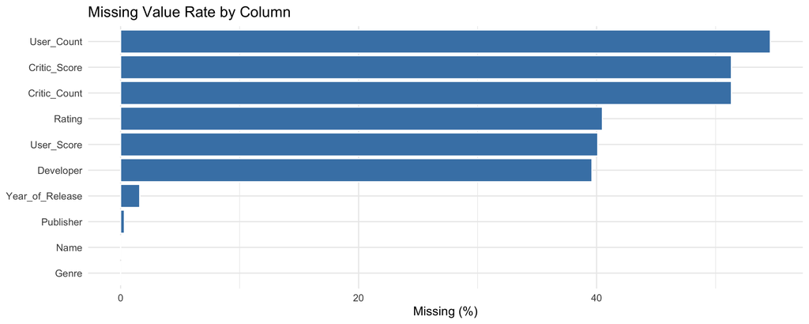

```r
col_summary(raw) %>%
  filter(null_pct > 0) %>%
  ggplot(aes(x = reorder(column, null_pct), y = null_pct)) +
  geom_col(fill = "steelblue", color = "white") +
  coord_flip() +
  labs(title = "Missing Value Rate by Column",
       x = NULL, y = "Missing (%)") +
  theme_minimal()
```

> **Observations:** - `Critic_Score`, `User_Score`, `Critic_Count`, `User_Count`, `Developer`, and `Rating` all have substantial missingness, these come from Metacritic and were not available for every title. - `Year_of_Release` and `Genre` have minor missingness. - Sales columns and `Name`/`Platform`/`Publisher` are nearly complete.

### 2b . Cleaning Steps

#### Remove Missing / Zero Target

We cannot model rows with no `Global_Sales` value.

```r
df <- raw %>% clean_target()
cat("Rows remaining:", nrow(df), "\n")
```

```
## Rows remaining: 16719
```

#### Clean Year of Release

`Year_of_Release` is stored as character (some entries are `"N/A"`). We coerce to integer and drop implausible values outside 1980–2020.

```r
df <- df %>% clean_year()
cat("Year range:", range(df$Year_of_Release), "\n")
```

```
## Year range: 1980 2020
```

#### Filter Valid Genres

Drop rows with missing or unrecognised genre values.

```r
df <- df %>% clean_genre()
cat("Genres present:", paste(sort(unique(df$Genre)), collapse = ", "), "\n")
```

```
## Genres present: Action, Adventure, Fighting, Misc, Platform, Puzzle, Racing, Role-Playing, Shooter, Simulation, Sports, Strategy
```

#### Clean User Score

`User_Score` contains `"tbd"` strings where a score hasn’t been assigned yet. We replace these with `NA` and convert the column to numeric.

```r
df <- df %>% clean_user_score()

cat("User_Score — NA count after cleaning:",
    sum(is.na(df$User_Score)), "\n")
```

```
## User_Score — NA count after cleaning: 8985
```

#### Standardise ESRB Rating

```r
df <- df %>% clean_rating()
df %>% count(Rating, sort = TRUE) %>% kable()
```

| Rating | n |
| --- | --- |
| Other | 6690 |
| E | 3922 |
| T | 2905 |
| M | 1536 |
| E10+ | 1393 |
| AO | 1 |
| RP | 1 |

### 2c. Cleaned Dataset Summary

```r
cat("Shape after cleaning:", nrow(df), "rows x", ncol(df), "cols\n\n")
```

```
## Shape after cleaning: 16448 rows x 16 cols
```

```r
col_summary(df) %>%
  arrange(desc(null_pct)) %>%
  kable(digits = 2, caption = "Missing Values — After Cleaning")
```

Missing Values — After Cleaning

| column | dtype | non_null | null_n | null_pct |
| --- | --- | --- | --- | --- |
| User_Score | numeric | 7463 | 8985 | 54.63 |
| User_Count | numeric | 7463 | 8985 | 54.63 |
| Critic_Score | numeric | 7983 | 8465 | 51.47 |
| Critic_Count | numeric | 7983 | 8465 | 51.47 |
| Developer | character | 9907 | 6541 | 39.77 |
| Publisher | character | 16416 | 32 | 0.19 |
| Name | character | 16448 | 0 | 0.00 |
| Platform | character | 16448 | 0 | 0.00 |
| Year_of_Release | integer | 16448 | 0 | 0.00 |
| Genre | character | 16448 | 0 | 0.00 |
| NA_Sales | numeric | 16448 | 0 | 0.00 |
| EU_Sales | numeric | 16448 | 0 | 0.00 |
| JP_Sales | numeric | 16448 | 0 | 0.00 |
| Other_Sales | numeric | 16448 | 0 | 0.00 |
| Global_Sales | numeric | 16448 | 0 | 0.00 |
| Rating | factor | 16448 | 0 | 0.00 |

### 2d. EDA

We will coerce all the remaining categorical variables to factors prior to doing EDA.

```r
df$Developer = as.factor(df$Developer)
df$Publisher = as.factor(df$Publisher)
df$Name = as.factor(df$Name)
df$Platform = as.factor(df$Platform)
df$Genre = as.factor(df$Genre)
```

A snippet of the first few rows in the dataframe:

```r
head(df)
```

```
## # A tibble: 6 × 16
##   Name       Platform Year_of_Release Genre Publisher NA_Sales EU_Sales JP_Sales
##   <fct>      <fct>              <int> <fct> <fct>        <dbl>    <dbl>    <dbl>
## 1 Wii Sports Wii                 2006 Spor… Nintendo      41.4    29.0      3.77
## 2 Super Mar… NES                 1985 Plat… Nintendo      29.1     3.58     6.81
## 3 Mario Kar… Wii                 2008 Raci… Nintendo      15.7    12.8      3.79
## 4 Wii Sport… Wii                 2009 Spor… Nintendo      15.6    10.9      3.28
## 5 Pokemon R… GB                  1996 Role… Nintendo      11.3     8.89    10.2
## 6 Tetris     GB                  1989 Puzz… Nintendo      23.2     2.26     4.22
## # ℹ 8 more variables: Other_Sales <dbl>, Global_Sales <dbl>,
## #   Critic_Score <dbl>, Critic_Count <dbl>, User_Score <dbl>, User_Count <dbl>,
## #   Developer <fct>, Rating <fct>
```

We now look at the datatypes of the variables in the dataframe after cleaning and factor coercion:

```r
str(df)
```

```
## tibble [16,448 × 16] (S3: tbl_df/tbl/data.frame)
##  $ Name           : Factor w/ 11429 levels "¡Shin Chan Flipa en colores!",..: 10932 9305 5504 10934 7328 9665 6617 10930 6620 2579 ...
##  $ Platform       : Factor w/ 31 levels "2600","3DO","3DS",..: 26 12 26 26 6 6 5 26 26 12 ...
##  $ Year_of_Release: int [1:16448] 2006 1985 2008 2009 1996 1989 2006 2006 2009 1984 ...
##  $ Genre          : Factor w/ 12 levels "Action","Adventure",..: 11 5 7 11 8 6 5 4 5 9 ...
##  $ Publisher      : Factor w/ 578 levels "10TACLE Studios",..: 370 370 370 370 370 370 370 370 370 370 ...
##  $ NA_Sales       : num [1:16448] 41.4 29.1 15.7 15.6 11.3 ...
##  $ EU_Sales       : num [1:16448] 28.96 3.58 12.76 10.93 8.89 ...
##  $ JP_Sales       : num [1:16448] 3.77 6.81 3.79 3.28 10.22 ...
##  $ Other_Sales    : num [1:16448] 8.45 0.77 3.29 2.95 1 0.58 2.88 2.84 2.24 0.47 ...
##  $ Global_Sales   : num [1:16448] 82.5 40.2 35.5 32.8 31.4 ...
##  $ Critic_Score   : num [1:16448] 76 NA 82 80 NA NA 89 58 87 NA ...
##  $ Critic_Count   : num [1:16448] 51 NA 73 73 NA NA 65 41 80 NA ...
##  $ User_Score     : num [1:16448] 8 NA 8.3 8 NA NA 8.5 6.6 8.4 NA ...
##  $ User_Count     : num [1:16448] 322 NA 709 192 NA NA 431 129 594 NA ...
##  $ Developer      : Factor w/ 1680 levels "10tacle Studios",..: 1022 NA 1022 1022 NA NA 1022 1022 1022 NA ...
##  $ Rating         : Factor w/ 8 levels "E","E10+","T",..: 1 7 1 1 7 7 1 1 1 7 ...
```

A summary of the dataframe showing basic statistics for each variable:

```r
summary(df)
```

```
##                           Name          Platform    Year_of_Release
##  Need for Speed: Most Wanted:   12   PS2    :2127   Min.   :1980
##  FIFA 14                    :    9   DS     :2122   1st Qu.:2003
##  LEGO Marvel Super Heroes   :    9   PS3    :1306   Median :2007
##  Ratatouille                :    9   Wii    :1286   Mean   :2006
##  Angry Birds Star Wars      :    8   X360   :1232   3rd Qu.:2010
##  Cars                       :    8   PSP    :1193   Max.   :2020
##  (Other)                    :16393   (Other):7182
##           Genre                             Publisher        NA_Sales
##  Action      :3308   Electronic Arts             : 1344   Min.   : 0.000
##  Sports      :2306   Activision                  :  976   1st Qu.: 0.000
##  Misc        :1721   Namco Bandai Games          :  935   Median : 0.080
##  Role-Playing:1483   Ubisoft                     :  930   Mean   : 0.264
##  Shooter     :1296   Konami Digital Entertainment:  825   3rd Qu.: 0.240
##  Adventure   :1293   (Other)                     :11406   Max.   :41.360
##  (Other)     :5041   NA's                        :   32
##     EU_Sales          JP_Sales         Other_Sales        Global_Sales
##  Min.   : 0.0000   Min.   : 0.00000   Min.   : 0.00000   Min.   : 0.0100
##  1st Qu.: 0.0000   1st Qu.: 0.00000   1st Qu.: 0.00000   1st Qu.: 0.0600
##  Median : 0.0200   Median : 0.00000   Median : 0.01000   Median : 0.1700
##  Mean   : 0.1459   Mean   : 0.07847   Mean   : 0.04758   Mean   : 0.5362
##  3rd Qu.: 0.1100   3rd Qu.: 0.04000   3rd Qu.: 0.03000   3rd Qu.: 0.4700
##  Max.   :28.9600   Max.   :10.22000   Max.   :10.57000   Max.   :82.5300
##
##   Critic_Score    Critic_Count      User_Score      User_Count
##  Min.   :13.00   Min.   :  3.00   Min.   :0.000   Min.   :    4
##  1st Qu.:60.00   1st Qu.: 12.00   1st Qu.:6.400   1st Qu.:   10
##  Median :71.00   Median : 22.00   Median :7.500   Median :   24
##  Mean   :68.99   Mean   : 26.44   Mean   :7.126   Mean   :  163
##  3rd Qu.:79.00   3rd Qu.: 36.00   3rd Qu.:8.200   3rd Qu.:   81
##  Max.   :98.00   Max.   :113.00   Max.   :9.700   Max.   :10665
##  NA's   :8465    NA's   :8465     NA's   :8985    NA's   :8985
##      Developer        Rating
##  Ubisoft  : 201   Other  :6690
##  EA Sports: 169   E      :3922
##  EA Canada: 164   T      :2905
##  Konami   : 158   M      :1536
##  Capcom   : 137   E10+   :1393
##  (Other)  :9078   AO     :   1
##  NA's     :6541   (Other):   1
```

We now calculate the number of rows with no missing values:

```r
sum(complete.cases(df))
```

```
## [1] 6889
```

We now present histograms and box plots for the relevant quantitative variables in the dataset: `Year_of_Release`, `Critic_Score`, `Critic_Count`, `User_Score`, `User_Count`. We do not show plots for `NA_Sales`, `EU_Sales`, `JP_Sales`, and `Other_Sales` since they can be aggregated to determine `Global_Sales` and therefore are not variables that will be used in our models.

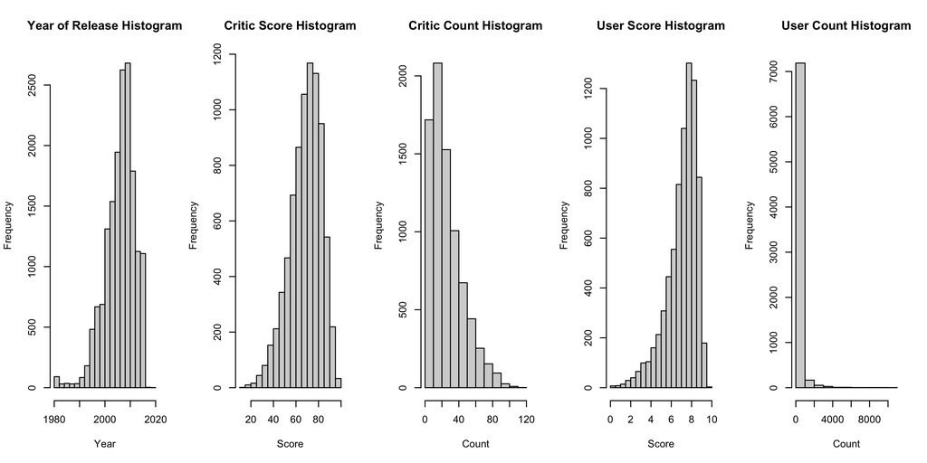

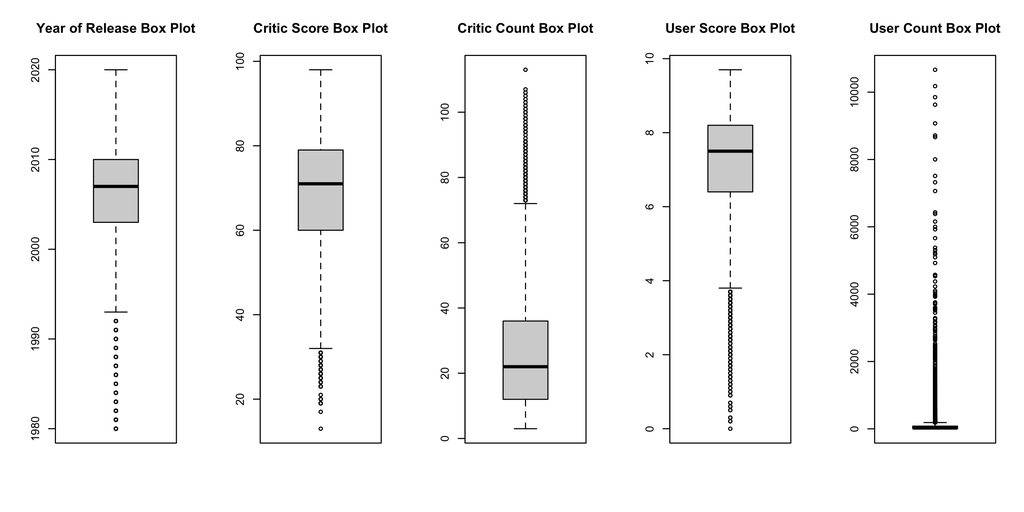

We now create a plot to see the correlation between `Critic_Score` and `User_Score`:

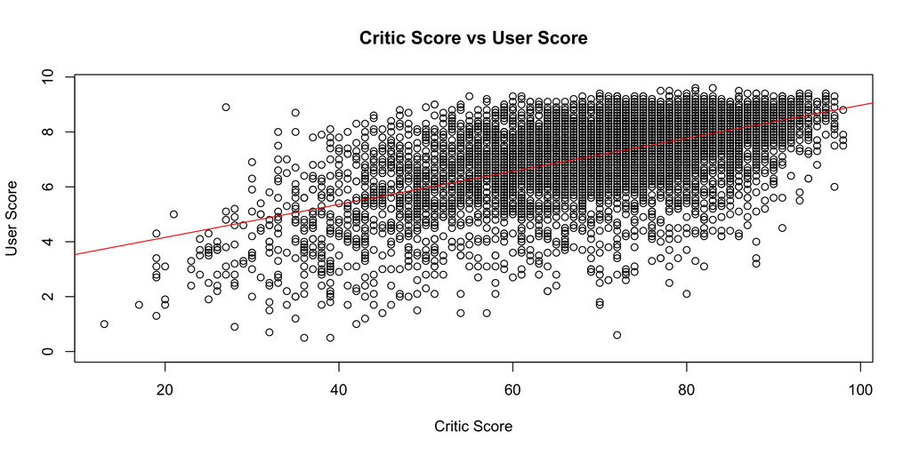

We now present bar plots for the relevant categorical variables in the dataset: `Platform`, `Genre`, and `Rating`. We do not show plots for `Developer` and `Publisher` due to their high number of factor levels and do not plot `Name` as it is an identifier for each title.

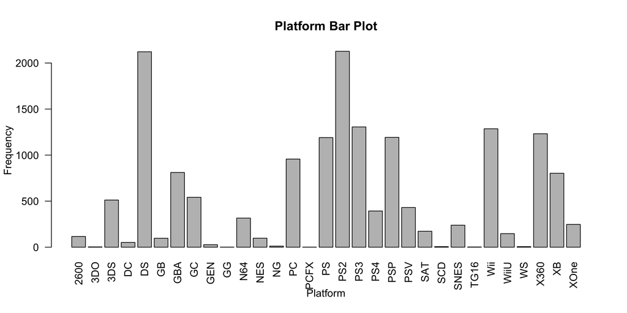

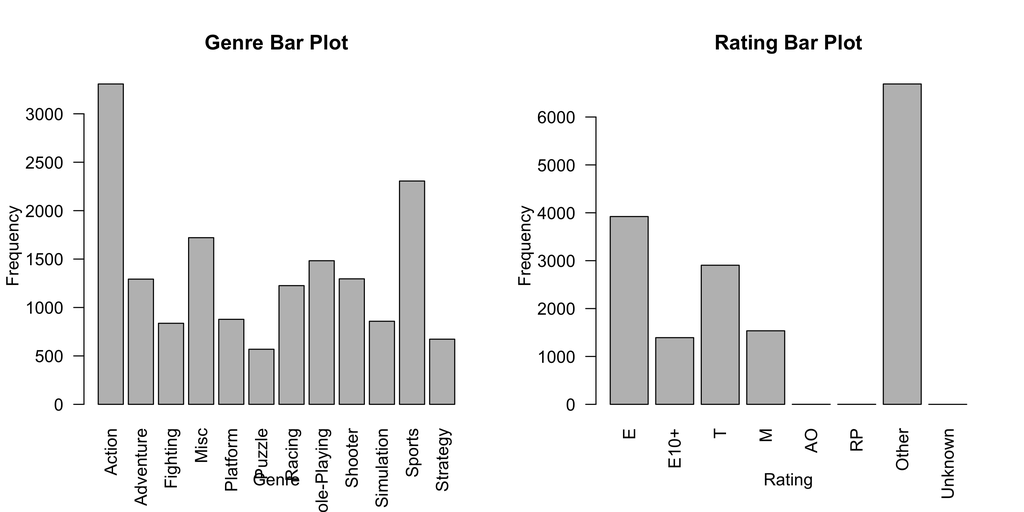